# 471-final-SVM

Guangjin Zhou

May 3, 2019

## Libraries

```r
library(ggplot2);library(e1071);library(pander)
```

## Bandruptcy Data

```
## [1] 3838   55
```

```
## [1] "0" "1"
```

```r
test<-read.table('C:/Users/gxz25/Documents/machine_learning_data_mining_class/471-final/testset',header = TRUE)
dim(test)
```

```
## [1] 1919   55
```

```r
test$V65f<-factor(test$V65);test$V65<-NULL
```

## Linear SVM model

### A smiple linear SVM model with cost as 1

```r
set.seed(471)
svmfit1 <- svm(V65f ~., data=train, kernel='linear',cost=1); summary(svmfit1)
```

```
##
## Call:
## svm(formula = V65f ~ ., data = train, kernel = "linear", cost = 1)
##
##
## Parameters:
##    SVM-Type:  C-classification
##  SVM-Kernel:  linear
##        cost:  1
##       gamma:  0.01851852
##
## Number of Support Vectors:  529
##
##  ( 273 256 )
##
##
## Number of Classes:  2
##
## Levels:
##  0 1
```

This model produced 529 Support Vectors (273 for 0 256 for 1).

### Partial dependence plots based sVM model

I plotted few top ranked important variables (V39, V35, V46 and V12) to look at their dependence.

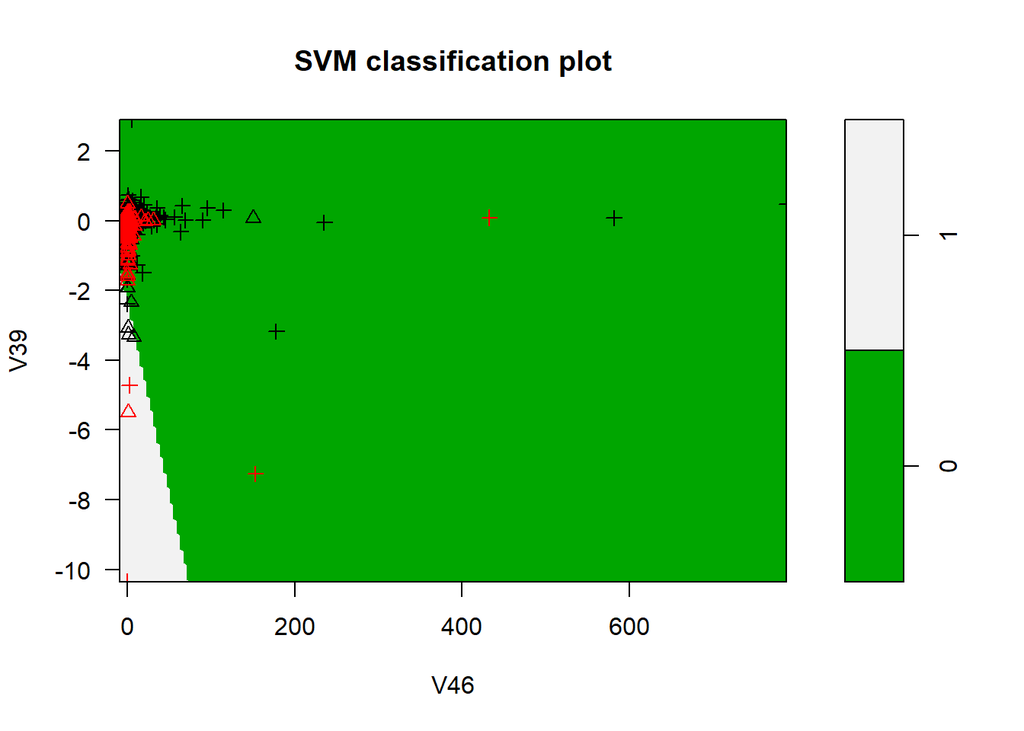

```r
plot(svmfit1, train,  V39~V46,grid=200, svSymbol=2, dataSymbol=3,color.palette=terrain.colors);
```

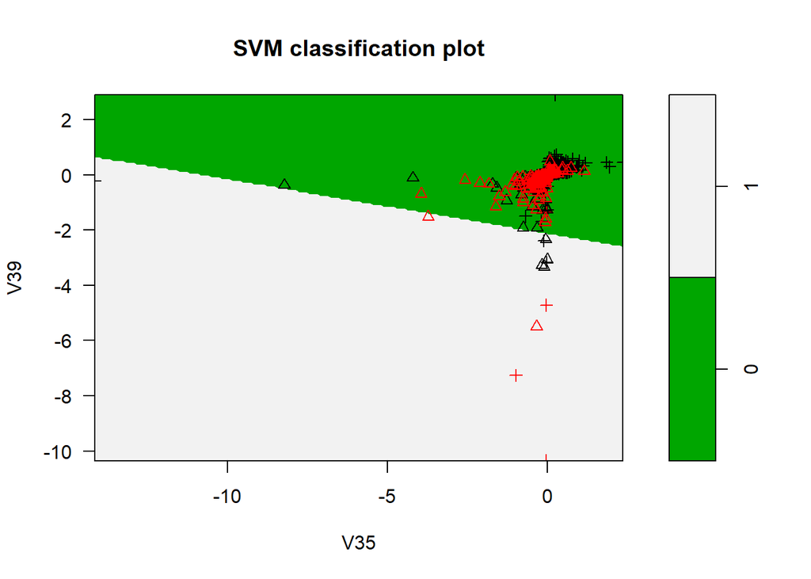

```r
plot(svmfit1, train,  V39~ V35,grid=200, svSymbol=2, dataSymbol=3,color.palette=terrain.colors)
```

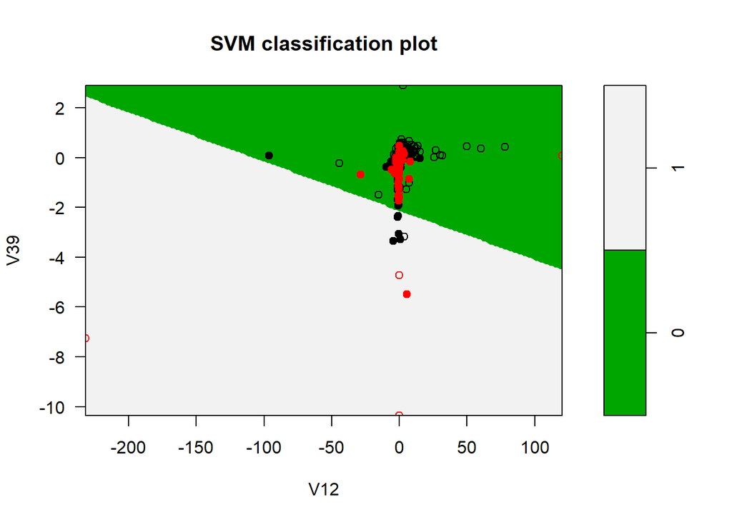

```r
plot(svmfit1, train, V39~V12, grid=200, svSymbol=19, dataSymbol=1, color.palette=terrain.colors)
```

### Prediction values and error rate from this SVM model

```r
table(train$V65f, svmfit1$fitted) ## training set error rate 250/3838 = 0.065
```

```
##
##        0    1
##   0 3575    1
##   1  249   13
```

```r
table(test$V65f, predict(svmfit1, test))  ## test set error rate 140/1919=0.073
```

```
##
##        0    1
##   0 1775    2
##   1  138    4
```

The mode predicts that training set error rate is 250/3838 = 0.065,test set error rate is: 140/1919=0.073.

### Linear SVM tuning

```r
set.seed(471)
tune.out <- tune(svm, V65f ~ ., data = train, kernel = "linear", ranges = list(cost = c(0.1,1,10)),tunecontrol = tune.control(nrepeat=5, cross=2))
print(summary(tune.out))
```

```
##
## Parameter tuning of 'svm':
##
## - sampling method: 2-fold cross validation
##
## - best parameters:
##  cost
##   0.1
##
## - best performance: 0.06591975
##
## - Detailed performance results:
##   cost      error  dispersion
## 1  0.1 0.06591975 0.007738011
## 2  1.0 0.06696196 0.005527150
## 3 10.0 0.06748306 0.005527150
```

The best performance of linear SVM has error rate as 0.06591975, which means the best performance model has the cost as 0.1.

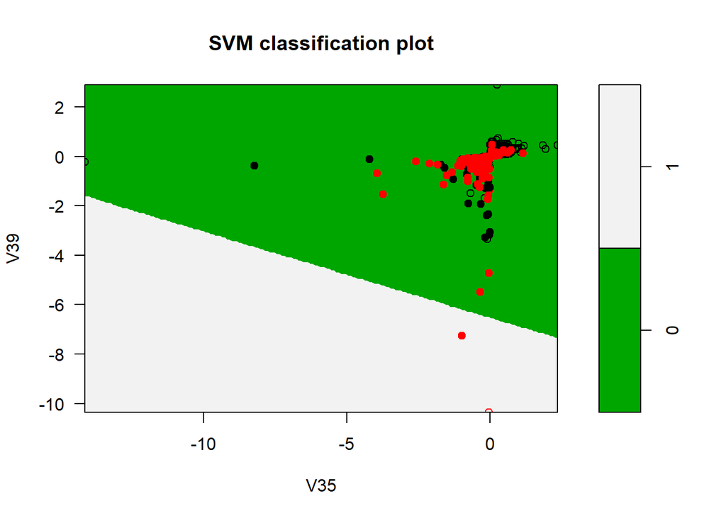

```r
plot(tune.out$best.model, train, V39~V35, grid=200, svSymbol=19, dataSymbol=1, color.palette=terrain.colors)
```

### Error rate from best performance linear kernal SVM

```r
table(train$V65f, tune.out$best.model$fitted) ## training set error rate 253/3838 = 0.06591975
```

```
##
##        0    1
##   0 3576    0
##   1  253    9
```

```r
table(test$V65f, predict(tune.out$best.model, test))  ## test set error rate 142/1919=0.07399687
```

```
##
##        0    1
##   0 1775    2
##   1  140    2
```

The tuned best performanc model predict that training set error rate is 253/3838 = 0.066, and the test set error rate 142/1919=0.074, which is very close to original model.

## kernel SVM tuning

```r
set.seed(471)
tune.out2 <- tune(svm, V65f ~ ., data = train, kernel = "radial", ranges = list(cost = c(0.1,1,10), gamma = c(0.5, 1)),tunecontrol = tune.control(nrepeat=5, cross=2))
print(summary(tune.out2))
```

```
##
## Parameter tuning of 'svm':
##
## - sampling method: 2-fold cross validation
##
## - best parameters:
##  cost gamma
##     1   0.5
##
## - best performance: 0.06800417
##
## - Detailed performance results:
##   cost gamma      error   dispersion
## 1  0.1   0.5 0.06826472 0.0044217204
## 2  1.0   0.5 0.06800417 0.0047901971
## 3 10.0   0.5 0.07191245 0.0007369534
## 4  0.1   1.0 0.06826472 0.0044217204
## 5  1.0   1.0 0.06852527 0.0033162903
## 6 10.0   1.0 0.07399687 0.0044217204
```

The best performance kernal model has error rate as 0.06800417, which means the best performance model has the cost as 1 and gamma as 0.5.

### A partial dependence plot with tuned model

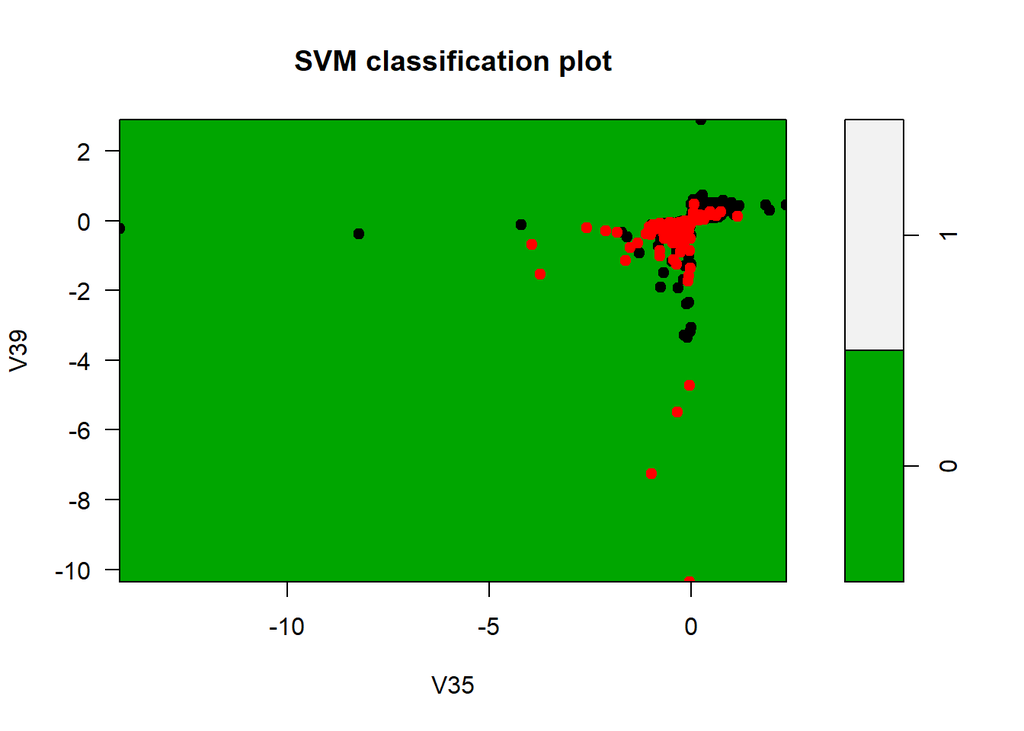

```r
plot(tune.out2$best.model, train, V39~V35, grid=200, svSymbol=19, dataSymbol=1, color.palette=terrain.colors)
```

### Error rate from best performance radinal kernal SVM

```r
table(train$V65f, tune.out2$best.model$fitted) ## training set error rate 161/3838 = 0.04194893
```

```
##
##        0    1
##   0 3572    4
##   1  157  105
```

```r
table(test$V65f, predict(tune.out2$best.model, test))  ## test set error rate 139/1919=0.07243356
```

```
##
##        0    1
##   0 1771    6
##   1  133    9
```

Based on the best performance kernal SVM model, the training set prediction error rate is 161/3838 = 0.042, andtest set error rate is 139/1919=0.072. Thus, I concluded that the tuned radinal kernal model has reduced error rate.